# DATA606_W1_Lab_1_MatheeshaThambeliyagodage

Matheesha Thambeliyagodage

February 9, 2017

Begin by loading the data set of 20,000 observations into the R workspace.

```r
library(DATA606)
#source("more/cdc.R")
#source("https://github.com/mathsanu/CUNY_MSDA/blob/master/DATA606/W1/lab_1/cdc.R")
source("http://www.openintro.org/stat/data/cdc.R")
names(cdc)
```

```
## [1] "genhlth"  "exerany"  "hlthplan" "smoke100" "height"   "weight"
## [7] "wtdesire" "age"      "gender"
```

```r
head(cdc)
```

```
##     genhlth exerany hlthplan smoke100 height weight wtdesire age gender
## 1      good       0        1        0     70    175      175  77      m
## 2      good       0        1        1     64    125      115  33      f
## 3      good       1        1        1     60    105      105  49      f
## 4      good       1        1        0     66    132      124  42      f
## 5 very good       0        1        0     61    150      130  55      f
## 6 very good       1        1        0     64    114      114  55      f
```

1.Make a scatterplot of weight versus desired weight. Describe the relationship between these two variables.

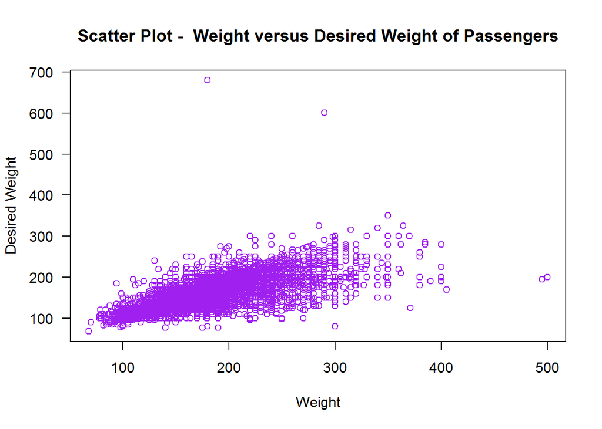

```r
plot(cdc$weight, main="Scatter Plot -  Weight versus Desired Weight of Passengers", cdc$wtdesire, xlab = "Weight", ylab = "Desired Weight",  col="purple", las = 1)
```

It appears to be a general positive correlation between the two variables weight versus desired weight, when desired weight increases weight also increses,although there is a great deal of spread. I assume they could be due to data entry mistakes (eg 700lb). – 2. Let’s consider a new variable: the difference between desired weight (wtdesire) and current weight (weight). Create this new variable by subtracting the two columns in the data frame and assigning them to a new object called wdiff.

```r
cdc$wdiff <- cdc$wtdesire - cdc$weight
#cdc$wdiff
names(cdc)
```

```
##  [1] "genhlth"  "exerany"  "hlthplan" "smoke100" "height"   "weight"
##  [7] "wtdesire" "age"      "gender"   "wdiff"
```

```r
head(cdc)
```

```
##     genhlth exerany hlthplan smoke100 height weight wtdesire age gender
## 1      good       0        1        0     70    175      175  77      m
## 2      good       0        1        1     64    125      115  33      f
## 3      good       1        1        1     60    105      105  49      f
## 4      good       1        1        0     66    132      124  42      f
## 5 very good       0        1        0     61    150      130  55      f
## 6 very good       1        1        0     64    114      114  55      f
##   wdiff
## 1     0
## 2   -10
## 3     0
## 4    -8
## 5   -20
## 6     0
```

3.What type of data is wdiff? If an observation wdiff is 0, what does this mean about the person’s weight and desired weight. What if wdiff is positive or negative?

wdiff is a scale variable an it is integer discrete because weights are integer values. Each record hase a wdiff value.

wdiff is equal to 0 means the person has the oplimal weight to the height or in their desired weight. wdiff > 0 then their weight is below their desired value, while wdiff < 0 implies that their actual weight is above their desired value. ——————– 4. Describe the distribution of wdiff in terms of its center, shape, and spread, including any plots you use. What does this tell us about how people feel about their current weight?

```r
summary(cdc$wdiff)
```

```
##    Min. 1st Qu.  Median    Mean 3rd Qu.    Max.
## -300.00  -21.00  -10.00  -14.59    0.00  500.00
```

```r
table(cdc$wdiff)
```

```
##
## -300 -246 -235 -220 -210 -200 -190 -180 -175 -170 -165 -160 -155 -152 -150
##    2    1    1    1    1    6    1    1    1    4    2    3    1    4   17
## -148 -147 -145 -142 -140 -139 -135 -133 -132 -130 -128 -126 -125 -122 -120
##    1    1    4    2    8    1    4    1    3   15    1    2    9    2   27
## -117 -115 -113 -112 -110 -109 -108 -107 -105 -103 -100  -99  -98  -97  -96
##    1   11    3    3   16    3    3    1   12    1  115    1    3    2    1
##  -95  -94  -93  -92  -91  -90  -88  -87  -86  -85  -84  -83  -82  -81  -80
##   11    2    2    2    1   46    6    2    5   22    3    4    5    2   72
##  -79  -78  -77  -76  -75  -74  -73  -72  -71  -70  -69  -68  -67  -66  -65
##    4    6    5    3   43    6    5    8    2  125    6    9    5    9   62
##  -64  -63  -62  -61  -60  -59  -58  -57  -56  -55  -54  -53  -52  -51  -50
##    8    8   10    4  184    8   15    8   12  101   13   11   14    4  395
##  -49  -48  -47  -46  -45  -44  -43  -42  -41  -40  -39  -38  -37  -36  -35
##   12   23   18   13  189   18   12   21    8  556   18   31   34   23  360
##  -34  -33  -32  -31  -30  -29  -28  -27  -26  -25  -24  -23  -22  -21  -20
##   32   30   28   22  893   36   70   65   26  677   47   70   74   41 1467
##  -19  -18  -17  -16  -15  -14  -13  -12  -11  -10   -9   -8   -7   -6   -5
##   43  141   69   73 1173   71  157  171   64 1856  103  234  234  132 1253
##   -4   -3   -2   -1    0    1    2    3    4    5    6    7    8    9   10
##  131  188  125   51 5616   19   39   33   21  232   34   58   43   17  333
##   11   12   13   14   15   16   17   18   19   20   21   22   23   24   25
##   20   32   23    8  208    5   13   14    9  151    2   17    9    5   79
##   26   27   28   29   30   31   32   33   35   36   37   38   39   40   41
##    3    9    9    1   46    2    5    6   26    3    3    1    1   21    3
##   42   43   45   47   50   52   53   55   60   61   63   64   65   68   70
##    2    1    7    1    9    1    1    2    6    1    1    2    5    1    3
##   72   73   75   80   83   85   86   90   91  110  311  500
##    1    1    1    2    1    2    1    1    1    1    1    1
```

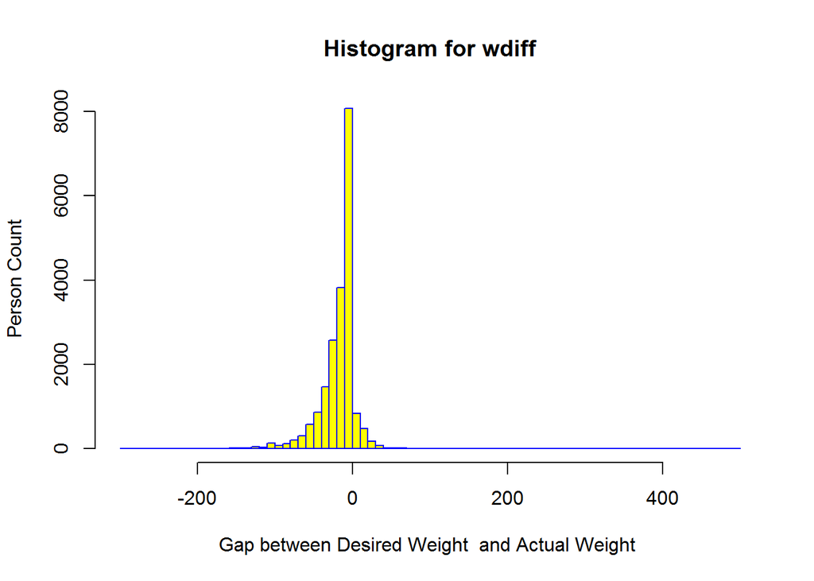

```r
hist(cdc$wdiff, ,main="Histogram for wdiff", breaks = 100,xlab="Gap between Desired Weight  and Actual Weight ", ylab = "Person Count",border="blue",     col="yellow")
```

–5.Using numerical summaries and a side-by-side box plot, determine if men tend to view their weight differently than women.

```r
summary(cdc$wdiff[cdc$gender == "m"])
```

```
##    Min. 1st Qu.  Median    Mean 3rd Qu.    Max.
## -300.00  -20.00   -5.00  -10.71    0.00  500.00
```

```r
summary(cdc$wdiff[cdc$gender == "f"])
```

```
##    Min. 1st Qu.  Median    Mean 3rd Qu.    Max.
## -300.00  -27.00  -10.00  -18.15    0.00   83.00
```

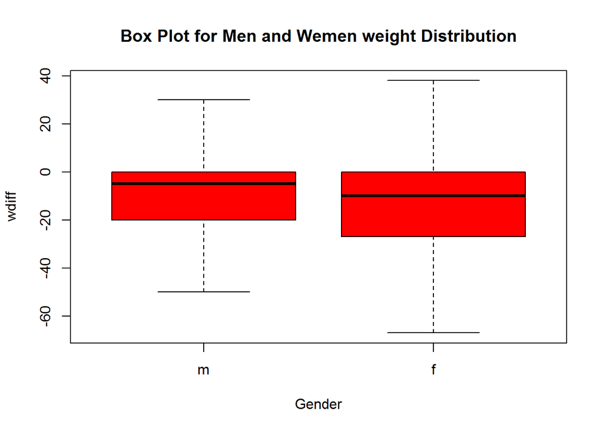

```r
boxplot(main="Box Plot for Men and Wemen weight Distribution", cdc$wdiff ~ cdc$gender, xlab="Gender",  ylab = "wdiff",col="Red", outline = F)
```

Above box plot and summary calculations shows median of women is lower than men. This means women are away from the desired weight than men (overweight women)

–6.Now it’s time to get creative. Find the mean and standard deviation of weight and determine what proportion of the weights are within one standard deviation of the mean.

```r
mean_weight <- mean(cdc$weight)
mean_weight
```

```
## [1] 169.683
```

```r
sd_weight <- sd(cdc$weight)
sd_weight
```

```
## [1] 40.08097
```

```r
weights_within_one_sd <- subset(cdc, weight < mean_weight + sd_weight & weight > mean_weight -
+ sd_weight)
weights_within_one_sd
```

[output not shown]

[output cut: 19986 more lines]

```r
dim(weights_within_one_sd)
```

```
## [1] 14152    10
```

There are 14152 observations in the required subset, out of a total of 20000 observations, this represents a proportion of 14152/20000 = 0.7076, or about 71%. Thus 71% of weights are within 1 standard deviation of the mean.